# Story 3: Firearm Mortality and Gun Control Laws

Mei Qi Ng

2026-10-10

## Approach & Methodology

In this assignment, I will be answer the critical public health question: “**Do stricter firearm control laws help reduce firearm mortality?**” The goal is to determine if firearm control laws correlate with reduced firearm mortality across U.S. states.

**Story Development Focus:** The focus is to understand whether firearm legislation is associated with firearm mortality. I will using claim, verification, and confirmation steps to investigate the public health question. First, a categorical comparison groups states by firearm law strictness is used to determine whether states with stricter laws experience lower firearm mortality overall. Next a state level scatter plot verifies if the relationship remains visible when all states are analyzed individually. Finally, geographic maps provide spatial confirmation by showing how regional patterns of legislative strictness align with firearm mortality patterns. With the use of the colorblind accessible viridis “mako” palette, standardize chart theme and highlights in the titles, the message is emphasized in the visuals so viewers can understand the key findings. The takeaway is that stronger firearm legislation is consistently associated with lower firearm mortality across categorical, state level, and geographic perspectives.

### **Deliverables:**

1. **Data Ingestion & Tidying:** Data integrates 2 primary sources:
   - **CDC Firearm Mortality Statistics:** Extracted dynamically from the CDC’s Vital Statistics API using `httr2`.
   - **Everytown Gun Law Strength Scores:** Ingested via standardized CSV data, scoring state legislative environments on a 100-point scale.

   Using `dplyr` and `tidyr`, the data is cleaned, joined, and categorized into a 5-point Likert scale (1 = Most Lax, 5 = Strictest) based on equal quintile distributions (`ntile(5)`).
2. **Summary Comparison (Graph 1):** A bar chart is utilized to compare the average mortality rates across the 5 Likert categories.
3. **Correlation Analysis (Graph 2):** A scatter plot with a linear trend line was chosen to evaluate the relationship between state level mortality and law strictness.
4. **Spatial Heat Maps (Graphs 3 & 4):** Two Side by side geographical maps was used to confirm regional trends.

Note: *For accessibility, the viridis color palette family package is used to ensure maximum readability for colorblind audience. State legislative strictness reflects active 2026 policy data, while the CDC API provides the latest annualized age-adjusted mortality estimates (2024/2025). This time lag is standard in public health data analysis due to the verification window required for state medical examiner records.*

# Data Pipeline: load, tidy and merge

```r
# Load packages and tidy Gun law CSV
library(tidyverse)
library(httr2)
library(usmap)
library(viridis)

gun_law <-read.csv("https://raw.githubusercontent.com/meiqing39/DATA-608/refs/heads/main/Story%203/Everytown-gun-laws-save-lives.csv")

# 1A Tidy and Create  5-point Likert scale for Gun Control Laws
# 1 = Most Lax, 2 = Lax, 3 = Moderate, 4 = Strict, 5 = Strictest

gun_laws <- gun_law|>
  rename(gunlaw_strength = Strength.of.Gun.Laws..out.of.100.points.,
         state = Label) |>
  mutate(state = state.name[match(str_trim(state), state.abb)]) |> # convert state to full state name to match cdc csv
  select(state, gunlaw_strength) |>
  mutate(Likert_Score = ntile(gunlaw_strength, 5), #split states to 5 equal bins base on score
    Likert_Category = factor(Likert_Score,
                             levels = 1:5,
                             labels = c("Most Lax", "Lax", "Moderate", "Strict", "Strictest"))
  )


# 1B. Request and Tidy CDC firearm mortality

cdc_req <- request("https://data.cdc.gov/resource/489q-934x.json") |>
  req_url_query(`$limit` = 5000)

# Perform request then parse JSON into a dataframe

cdc_resp <- req_perform(cdc_req)

cdc_api <- resp_body_json(cdc_resp, simplifyVector = TRUE) |> as_tibble()


cdc_clean <- cdc_api|>
  filter(cause_of_death == "Firearm-related injury",
         rate_type == "Age-adjusted",
         time_period == "12 months ending with quarter") |>
  pivot_longer(cols = starts_with("rate_"), names_to = "raw_col", values_to = "Mortality_Rate") |> #pivot all state name column with rate_
  mutate(
    Mortality_Rate = suppressWarnings(as.numeric(Mortality_Rate)),
    name = str_remove(raw_col, "rate_"),
    name = str_replace_all(name, "_", " "),
    state = str_to_title(name) #capitalize beginning letter
  ) |>
  filter(state %in% state.name) |>
  drop_na(Mortality_Rate) |>
  arrange(desc(year_and_quarter)) |>
  group_by(state) |>
  slice(1) |>
  ungroup() |>
  select(state, Mortality_Rate)


# 1c. Merge datasets
combo <- gun_laws |>
  left_join(cdc_clean, by = "state")

head(combo)
```

```
##        state gunlaw_strength Likert_Score Likert_Category Mortality_Rate
## 1    Alabama            16.0            3        Moderate           22.1
## 2     Alaska             9.0            2             Lax           25.0
## 3    Arizona             8.0            1        Most Lax           17.1
## 4   Arkansas             4.5            1        Most Lax           19.6
## 5 California            91.0            5       Strictest            6.7
## 6   Colorado            69.5            4          Strict           15.1
```

# Categorical Analysis: Macro View

To understand if gun legislation impacts public health, I aggregated the states into 5 Likert tier/categories based on their Everytown gun law strength scores, ranging from “Most Lax” to “Strictest.” By calculating the average CDC mortality rate for each category, a clear macro level trend emerges from the data.

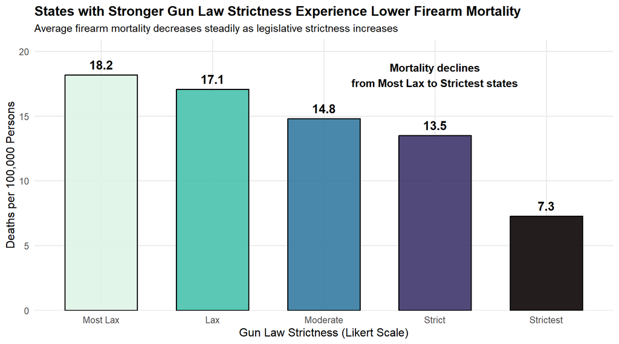

```r
stats <- combo |>   #collect mean by Likert bin
  summarize(.by = Likert_Category,
            Avg_Mortality = mean(Mortality_Rate, na.rm = TRUE),
            State_Count = n()) |>
  arrange(Likert_Category)


# Graph 1:  Bar Chart
ggplot(stats, aes(x = Likert_Category, y = Avg_Mortality, fill = Likert_Category))+
  geom_col(color = "black", width = 0.65, alpha = 0.9) +
  geom_text(aes(label = round(Avg_Mortality, 1)), vjust = -0.6, fontface = "bold", size = 4.5) +
  scale_fill_viridis_d(option = "mako", direction = -1) +
  scale_y_continuous(expand = expansion(mult = c(0, 0.15))) +
  labs(title = "States with Stronger Gun Law Strictness Experience Lower Firearm Mortality",
       subtitle = "Average firearm mortality decreases steadily as legislative strictness increases",
       x = "Gun Law Strictness (Likert Scale)",
       y = "Deaths per 100,000 Persons") +
  annotate(
  "text",
  x = 4,
  y = max(stats$Avg_Mortality) * 1,
  label = "Mortality declines\nfrom Most Lax to Strictest states",
  fontface = "bold",
  size =4
)+
  theme_minimal(base_size = 12) +
  theme(legend.position = "none",
        plot.title = element_text(face = "bold", size = 14),
        plot.subtitle = element_text(size =11),
        panel.grid.minor =element_blank())
```

The bar chart shows a obvious inverse relationship. States categorized as having the “Most Lax” laws suffer an average mortality rate that is much higher than states in the “Strictest” category.

# Correlation Analysis: Micro View

Aggregated averages sometimes hides outlier/variances. To look into this, I decided to plot all 50 states individually to check if this downward trend is consistent.

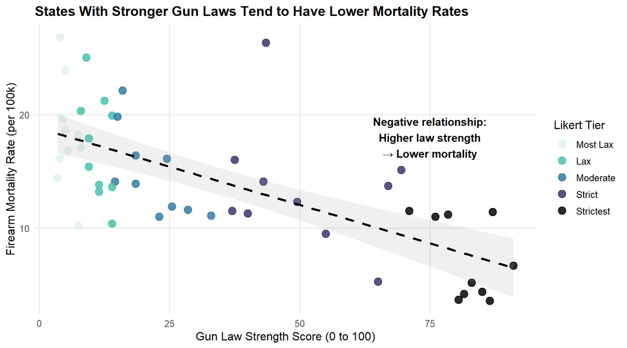

```r
# Graph 2: Scatter Plot with Regression Trend
ggplot(combo, aes(x = gunlaw_strength, y = Mortality_Rate)) +
  geom_point(aes(color = Likert_Category), size = 3.5, alpha = 0.85) +
  geom_smooth(method = "lm", color = "black", linetype = "dashed", se = TRUE, alpha = 0.15) +
  scale_color_viridis_d(option = "mako", direction = -1) +
  labs(title = "States With Stronger Gun Laws Tend to Have Lower Mortality Rates",
       x = "Gun Law Strength Score (0 to 100)",
       y = "Firearm Mortality Rate (per 100k)",
       color = "Likert Tier") +
  annotate(
  "text",
  x = 75,
  y = 18,
  label = "Negative relationship:\nHigher law strength\n→ Lower mortality",
  fontface = "bold",
  size = 4)+
  theme_minimal(base_size = 12) +
  theme(
    panel.grid.minor = element_blank(),
    plot.title = element_text(face = "bold", size = 14)
  )
```

This chart shows the visible negative correlation (strong negative slope); as a state’s gun law strenght score increases, the corresponding mortality rate on the y axis drops. High mortality rates are concentrated among states with law strength scores under 20.

# Quantifying the Relationship

```r
cor(combo$gunlaw_strength,combo$Mortality_Rate)
```

```
## [1] -0.6945787
```

```r
model <- lm(
  Mortality_Rate ~ gunlaw_strength,
  data = combo)

summary(model)
```

```
##
## Call:
## lm(formula = Mortality_Rate ~ gunlaw_strength, data = combo)
##
## Residuals:
##     Min      1Q  Median      3Q     Max
## -7.5761 -3.2831 -0.2503  2.5602 13.3815
##
## Coefficients:
##                 Estimate Std. Error t value Pr(>|t|)
## (Intercept)     18.78812    0.90841  20.682  < 2e-16 ***
## gunlaw_strength -0.13493    0.02017  -6.689 2.21e-08 ***
## ---
## Signif. codes:  0 '***' 0.001 '**' 0.01 '*' 0.05 '.' 0.1 ' ' 1
##
## Residual standard error: 4.172 on 48 degrees of freedom
## Multiple R-squared:  0.4824, Adjusted R-squared:  0.4717
## F-statistic: 44.74 on 1 and 48 DF,  p-value: 2.206e-08
```

The negative relationship is statistically consistent; the correlation coefficient indicates that increase in firearm law strength are associated with decrease in firearm mortality. In addition, the regression model shows that states with stronger firearm laws experience lower firearm mortality, reinforces the visual trend seen in the scatter plot previously.

# Spatial Heat Map: Geographic View

Public heath and policies are related and tied to the location. By looking at where these policies are implemented and where the death is occurring, we can further explore how firearm mortality vary by state.

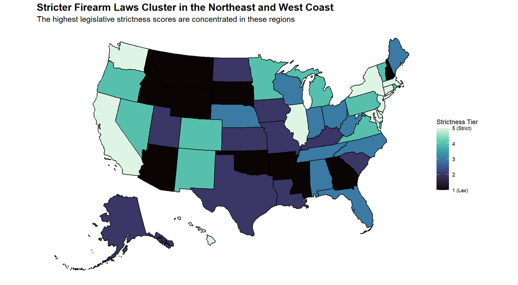

```r
# Graph 3: Legislative Strictness Map
map_laws <- plot_usmap(data = combo, values = "Likert_Score", regions = "states") +
  scale_fill_viridis_c(option = "mako",
                       breaks = 1:5,
                       labels = c("1 (Lax)", "2", "3", "4", "5 (Strict)"),
                       name = "Strictness Tier") +
  labs(title = "Stricter Firearm Laws Cluster in the Northeast and West Coast",
       subtitle = "The highest legislative strictness scores are concentrated in these regions") +
  theme(legend.position = "right",
        plot.title = element_text(face = "bold", size = 14),
        plot.subtitle = element_text(size =11),
        panel.grid.minor =element_blank())
# Graph 4: Mortality Heat Map
map_mortality <- plot_usmap(data = combo, values = "Mortality_Rate", regions = "states") +
  scale_fill_viridis_c(option = "mako",
                       direction = -1,
                       name = "Deaths / 100k") +
  labs(title = "Higher Firearm Mortality Clusters in the South and Mountain West",
       subtitle = "Regions with weaker firearm laws display higher mortality rates") +
  theme(legend.position = "right",
        plot.title = element_text(face = "bold", size = 14),
        plot.subtitle = element_text(size =11),
        panel.grid.minor =element_blank())

# Final output
map_laws
```

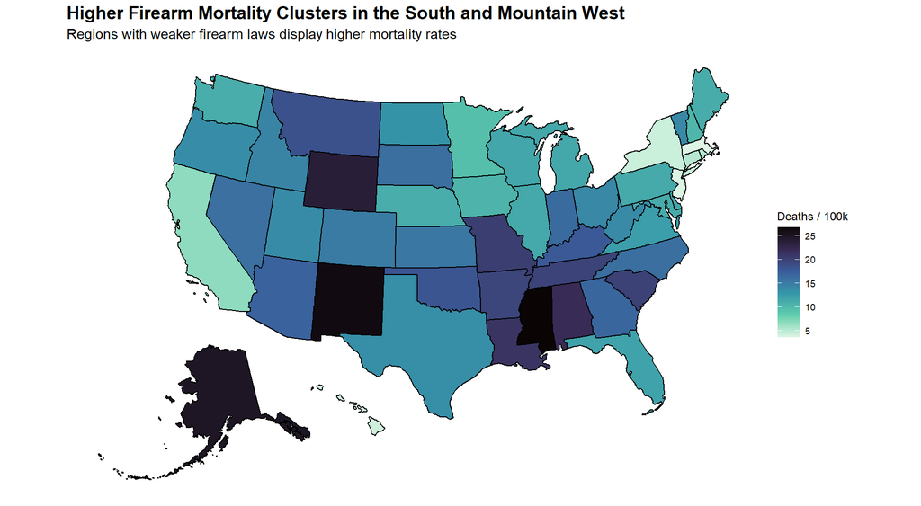

```r
map_mortality
```

Spatial patterns function as visual counterparts: * High legislative strictness scores in the West Coast (CA, OR, WA) and the Northeast (NY, NJ, MA) corresponds to the lowest firearm mortality rates

- low scored legal states are clustered through the South (MS, LA, AL) and Mountain West (WY, MT), matches the highest mortality rates in the country.

# Findings

Analyzing the CDC mortality records with the state gun policy pointed to a definite answer to the assignment question: **Yes, stricter firearm control laws are strongly associated with reduced firearm mortality.**

These results indicate that state-level firearm legislation serves as a important and measurable protective factor against firearm mortality.